# Manipulating and tidying Accidental Drug Deaths Data in R: Techniques and Insights

Merishna Singh Suwal

## Abstract

Accidental drug deaths have become a growing public health concern in recent times. The need for effective prevention and control measures necessitates comprehensive data analysis and insights. The case study presents an analysis of accidental drug deaths data in Connecticut from 2012 to 2021, utilizing R programming language and its libraries, including dplyr and ggplot2, to extract valuable insights through data manipulation techniques.

**Keywords:** Accidental drug deaths, Prevention, Data analysis, Data manipulation

## 1. Introduction

### 1.1. Literature Review

Drug overdose deaths have been a growing problem in the United States in recent years, and accurate data analysis is essential for developing effective prevention and control measures. This literature review provides an overview of the significance of data manipulation methods in deriving meaningful insights from intricate and large data sets, with a particular focus on accidental drug deaths.

Data manipulation and tidying are essential parts of the data analysis process, as they help transform raw data into a format that is more easily understandable and useful for decision-making. This process involves tasks such as cleaning, transforming, and restructuring data to identify trends and patterns that can provide valuable insights into drug overdose deaths. Several studies have examined drug deaths data in Connecticut and the insights that can be derived from manipulating and tidying this data. One study analyzed data from the Centers for Disease Control and Prevention (CDC) on opioid overdose deaths between 2000 and 2015. This study aimed to investigate the racial and ethnic differences in opioid overdose deaths in the United States. The researchers found that while all racial and ethnic groups experienced an increase in opioid overdose deaths during this period, the rate of increase was highest among non-Hispanic whites. The study also found that the rate of opioid overdose deaths was significantly higher among non-Hispanic whites and American Indian/Alaska Natives compared to other racial and ethnic groups. The findings suggest that targeted interventions are needed to address the racial and ethnic disparities in opioid overdose deaths in the United States.

The insights derived from data manipulation and tidying in these studies have important policy implications. Policymakers and public health authorities can use this information to develop targeted prevention and control measures that address the specific needs of high-risk groups. These measures can include initiatives such as public education campaigns, improved access to addiction treatment services, and stricter regulations on prescription drug use.

### 1.2. Data Overview and Utilization

The data set **Accidental Drug Related Deaths from 2012-2021 in Connecticut** has been derived from Connecticut Open Data Repository (Connecticut Data, 2021). Drug overdose is one of the leading causes of injury-related deaths in the U.S (Hedegaard, Minino, & Warner, 2020). An estimated number of 100,000 people have died in between April 2020 to 2021 due to drug overdoses, which was an increase of 28.5% from the previous year according to the CDC (2021).

The data set was collected by the Office of the Chief Medical Examiner in Connecticut through an investigation process that includes a toxicity report, death certificate, and a scene investigation. It includes 48 columns with information such as the number of deaths, demographic information of those who died (such as age, race, and gender), and the location and substances detected in the overdose for 9202 individuals.

```r
# Read data set and check number of rows and columns
data <- read_csv('Accidental_Drug_Related_Deaths_2012-2021.csv', show_col_types = FALSE)
```

The data set contains the following columns that describe the demographics of the patients such as their age, race, ethnicity, location and the kind of drug toxicity:

```r
# column names
names(data)
```

```
##  [1] "Date"                          "Date Type"
##  [3] "Age"                           "Sex"
##  [5] "Race"                          "Ethnicity"
##  [7] "Residence City"                "Residence County"
##  [9] "Residence State"               "Injury City"
## [11] "Injury County"                 "Injury State"
## [13] "Injury Place"                  "Description of Injury"
## [15] "Death City"                    "Death County"
## [17] "Death State"                   "Location"
## [19] "Location if Other"             "Cause of Death"
## [21] "Manner of Death"               "Other Significant Conditions"
## [23] "Heroin"                        "Heroin death certificate (DC)"
## [25] "Cocaine"                       "Fentanyl"
## [27] "Fentanyl Analogue"             "Oxycodone"
## [29] "Oxymorphone"                   "Ethanol"
## [31] "Hydrocodone"                   "Benzodiazepine"
## [33] "Methadone"                     "Meth/Amphetamine"
## [35] "Amphet"                        "Tramad"
## [37] "Hydromorphone"                 "Morphine (Not Heroin)"
## [39] "Xylazine"                      "Gabapentin"
## [41] "Opiate NOS"                    "Heroin/Morph/Codeine"
## [43] "Other Opioid"                  "Any Opioid"
## [45] "Other"                         "ResidenceCityGeo"
## [47] "InjuryCityGeo"                 "DeathCityGeo"
```

Here is a sample of six rows of the data:

```r
# sample of the data set
head(data)
```

| Date | Date Type | Age | Sex | Race | Ethnicity | Residence City | Residence County | Residence State | Injury City | Injury County | Injury State | Injury Place | Description of Injury | Death City | Death County | Death State | Location | Location if Other | Cause of Death | Manner of Death | Other Significant Conditions | Heroin | Heroin death certificate (DC) | Cocaine | Fentanyl | Fentanyl Analogue | Oxycodone | Oxymorphone | Ethanol | … |
| --- | --- | --- | --- | --- | --- | --- | --- | --- | --- | --- | --- | --- | --- | --- | --- | --- | --- | --- | --- | --- | --- | --- | --- | --- | --- | --- | --- | --- | --- | --- |
| 05/29/2012 | Date of death | 37 | Male | Black | NA | STAMFORD | FAIRFIELD | NA | STAMFORD | NA | CT | Residence | Used Cocaine | NA | NA | NA | Residence | NA | Cocaine Toxicity | Accident | NA | NA | NA | Y | NA | NA | NA | NA | NA | … |
| 06/27/2012 | Date of death | 37 | Male | White | NA | NORWICH | NEW LONDON | NA | NORWICH | NA | CT | Residence | Drug Use | NORWICH | NEW LONDON | NA | Hospital | NA | Heroin Toxicity | Accident | NA | Y | NA | NA | NA | NA | NA | NA | NA | … |
| 03/24/2014 | Date of death | 28 | Male | White | NA | HEBRON | NA | NA | HEBRON | NA | CT | Residence | Drug Use | MARLBOROUGH | NA | NA | Hospital | NA | Heroin Intoxication | Accident | NA | Y | NA | NA | NA | NA | NA | NA | NA | … |
| 12/31/2014 | Date of death | 26 | Female | White | NA | BALTIC | NA | NA | NA | NA | NA | NA | NA | BALTIC | NEW LONDON | NA | Residence | NA | Acute Heroin Intoxication | Accident | NA | Y | NA | NA | NA | NA | NA | NA | NA | … |
| 01/16/2016 | Date of death | 41 | Male | White | NA | SHELTON | FAIRFIELD | CT | SHELTON | NA | NA | Residence | Drug Use | BRIDGEPORT | NA | NA | Hospital | NA | Acute Fentanyl Intoxication | Accident | NA | NA | NA | NA | Y | NA | NA | NA | NA | … |
| 06/13/2017 | Date reported | 57 | Male | White | NA | BLANDFORD | HAMPDEN | MA | ENFIELD | HARTFORD | CT | In Vehicle | Drug abuse | ENFIELD | HARTFORD | CT | Other | Roadway in vehicle | Acute Intoxication Cocaine Toxicity | Accident | NA | NA | NA | Y | NA | NA | NA | NA | NA | … |

**Table 1.2 :** Sample of the data

Accidental drug deaths data is essential for health professionals, particularly those working in public health, epidemiology, substance abuse treatment, and healthcare delivery. This data can provide valuable insights into drug overdose trends, help identify patterns and high-risk populations, and inform public health policies and interventions.The power of data in healthcare cannot be understated, especially when it comes to understanding the extent of drug abuse and overdose within a specific population. With the Accidental Drug Related Deaths data, healthcare professionals have a unique opportunity to gain deep insights into drug-related death trends and patterns that can be used to inform the development of targeted prevention and intervention strategies.

By using data transformation and visualization methods, healthcare professionals can more effectively identify high-risk groups and develop preventative measures such as education programs and harm reduction strategies. The visualizations can help them analyze the data and understand the types of drugs involved, the demographics of the victims, and the geographical distribution of incidents. This information can be leveraged to monitor the prevalence and incidence of drug overdoses in specific populations or geographical areas and inform public health policy and intervention strategies.

## 2. Methodology

### 2.1. Data Tidying Techniques

The data set obtained is a **raw** data set, meaning, it might have issues with inconsistencies in the data formatting and the way columns are arranged. We will now illustrate the use of a series of commands in order to make this data set “tidy”. A tidy data set can be used for performing robust analysis and gaining insights from the data which are not biased or error-prone.

1. As illustrated from the data **Table 1** above, the `Date` column contains values for both `Date of death` and `Date reported`, which makes the data set unclear and untidy. Hence, the columns depicting `Date` and `Date Type` need to be changed to depict `Date of death` and `Date reported` columns instead by using a pivoting technique. The `pivot_wider()` method should be used to add two columns `date of death` and `date reported` on a new data frame `new_data`.

```r
# Changing date of death and date reported columns using pivoting

new_data_reorder <- data %>%
  pivot_wider(
    names_from = `Date Type`,
    values_from = c(Date)
  )

sample(new_data_reorder[, c('Date of death','Date reported')])
```

| Date reported | Date of death |
| --- | --- |
| NA | 05/29/2012 |
| NA | 06/27/2012 |
| NA | 03/24/2014 |
| NA | 12/31/2014 |
| NA | 01/16/2016 |
| 06/13/2017 | NA |
| 10/20/2015 | NA |
| 02/02/2017 | NA |
| NA | 07/03/2018 |
| NA | 05/08/2013 |

[output cut: 9192 more lines]

2. The value in the column `ResidenceCityGeo`, `InjuryCityGeo`and `DeathCityGeo` should be divided into two columns `City` and `CityGeo` respectively. Also, the City contains the “CT” state value is is redundant. To separate the redundant values in the columns `ResidenceCityGeo`, `InjuryCityGeo`and `DeathCityGeo`, the `separate()` method is used which results in a cleaner data set as follows.

```r
# separating the value of column into multiple columns using separate method

# Separating City and Geo location
new_data_formatted <- separate(data = new_data_reorder, col = ResidenceCityGeo, into = c("Residence City", "ResidenceCityGeo"), sep = "\\\n", remove = TRUE)

# Separating City and State
new_data_formatted2 <- separate(data = new_data_formatted, col = `Residence City`, into = c("Residence City", "State"), sep = ", ", remove = TRUE)

# Separating City and Geo location
new_data_formatted3 <- separate(data = new_data_formatted2, col = DeathCityGeo, into = c("Death City", "DeathCityGeo"), sep = "\\\n", remove = TRUE)

# Separating City and State
new_data_formatted4 <- separate(data = new_data_formatted3, col = `Death City`, into = c("Death City", "State"), sep = ", ", remove = TRUE)

# Separating City and Geo location
new_data_formatted5 <- separate(data = new_data_formatted4, col = InjuryCityGeo, into = c("Injury City", "InjuryCityGeo"), sep = "\\\n", remove = TRUE)

# Separating City and State
new_data_formatted6 <- separate(data = new_data_formatted5, col = `Injury City`, into = c("Injury City", "State"), sep = ", ", remove = TRUE)

# preview the formatted data
head(new_data_formatted6[, c("Residence City", "ResidenceCityGeo", "Injury City", "InjuryCityGeo", "Death City", "DeathCityGeo")])
```

| Residence City | ResidenceCityGeo | Injury City | InjuryCityGeo | Death City | DeathCityGeo |
| --- | --- | --- | --- | --- | --- |
| STAMFORD | (41.051924, -73.539475) | STAMFORD | (41.051924, -73.539475) | CT | (41.575155, -72.738288) |
| NORWICH | (41.524304, -72.075821) | NORWICH | (41.524304, -72.075821) | Norwich | (41.524304, -72.075821) |
| HEBRON | (41.658069, -72.366324) | HEBRON | (41.658069, -72.366324) | Marlborough | (41.632043, -72.461309) |
| BALTIC | (41.617221, -72.085031) | CT | (41.575155, -72.738288) | Baltic | (41.617221, -72.085031) |
| SHELTON | (41.316843, -73.092968) | SHELTON | (41.316843, -73.092968) | Bridgeport | (41.179195, -73.189476) |
| NA | NA | ENFIELD | (41.976501, -72.591985) | Enfield | (41.976501, -72.591985) |

3. Fill the null values for different columns.

Firstly, we need to fill the null values in the columns that present the drug detected (Y/N) to ‘N’ in cases of `NA`. In order to address the problem of null data values, the `replace_na()` method is used.

```r
new_data_fill <- new_data_formatted6 %>%
  mutate_at(c("Heroin", "Cocaine", "Fentanyl", "Fentanyl Analogue", "Oxycodone", "Oxymorphone", "Ethanol", "Hydrocodone", "Benzodiazepine", "Methadone", "Meth/Amphetamine", "Amphet", "Tramad", "Hydromorphone", "Morphine (Not Heroin)", "Xylazine", "Gabapentin", "Opiate NOS", "Heroin/Morph/Codeine", "Other Opioid", "Any Opioid", "Other"), ~replace_na(., "N"))

# view a sample
head(new_data_fill[,c("Heroin", "Cocaine", "Fentanyl", "Fentanyl Analogue", "Oxycodone", "Oxymorphone", "Ethanol", "Hydrocodone", "Benzodiazepine", "Methadone", "Meth/Amphetamine", "Amphet", "Tramad", "Hydromorphone", "Morphine (Not Heroin)", "Xylazine", "Gabapentin", "Opiate NOS", "Heroin/Morph/Codeine", "Other Opioid", "Any Opioid", "Other")])
```

| Heroin | Cocaine | Fentanyl | Fentanyl Analogue | Oxycodone | Oxymorphone | Ethanol | Hydrocodone | Benzodiazepine | Methadone | Meth/Amphetamine | Amphet | Tramad | Hydromorphone | Morphine (Not Heroin) | Xylazine | Gabapentin | Opiate NOS | Heroin/Morph/Codeine | Other Opioid | Any Opioid | Other |
| --- | --- | --- | --- | --- | --- | --- | --- | --- | --- | --- | --- | --- | --- | --- | --- | --- | --- | --- | --- | --- | --- |
| N | Y | N | N | N | N | N | N | N | N | N | N | N | N | N | N | N | N | N | N | N | N |
| Y | N | N | N | N | N | N | N | N | N | N | N | N | N | N | N | N | N | N | N | N | N |
| Y | N | N | N | N | N | N | N | N | N | N | N | N | N | N | N | N | N | N | N | N | N |
| Y | N | N | N | N | N | N | N | N | N | N | N | N | N | N | N | N | N | N | N | N | N |
| N | N | Y | N | N | N | N | N | N | N | N | N | N | N | N | N | N | N | N | N | Y | N |
| N | Y | N | N | N | N | N | N | N | N | N | N | N | N | N | N | N | N | N | N | N | N |

Similarly, the `Age` column can be filled with the median value of the Age.

```r
# Calculate the median of the non-missing values
median_age <- median(new_data_fill$Age, na.rm = TRUE)

# Replace missing values with the median
new_data_fill <- new_data_fill %>%
  mutate_at(c("Age"), ~replace_na(., median_age))

tail(new_data_fill[, c("Age")], 10)
```

| Age |
| --- |
| 45 |
| 46 |
| 41 |
| 50 |
| 54 |
| 56 |
| 48 |
| 59 |
| 68 |
| 29 |

The null values in most columns such as `Ethnicity` can be filled with `"Unknown"`.

```r
data_tidy <- new_data_fill %>% replace(is.na(.), "Unknown")

head(data_tidy)
```

| Age | Sex | Race | Ethnicity | Residence County | Residence State | Injury County | Injury State | Injury Place | Description of Injury | Death County | Death State | Location | Location if Other | Cause of Death | Manner of Death | Other Significant Conditions | Heroin | Heroin death certificate (DC) | Cocaine | Fentanyl | Fentanyl Analogue | Oxycodone | Oxymorphone | Ethanol | Hydrocodone | Benzodiazepine | Methadone | Meth/Amphetamine | Amphet | … |
| --- | --- | --- | --- | --- | --- | --- | --- | --- | --- | --- | --- | --- | --- | --- | --- | --- | --- | --- | --- | --- | --- | --- | --- | --- | --- | --- | --- | --- | --- | --- |
| 37 | Male | Black | Unknown | FAIRFIELD | Unknown | Unknown | CT | Residence | Used Cocaine | Unknown | Unknown | Residence | Unknown | Cocaine Toxicity | Accident | Unknown | N | Unknown | Y | N | N | N | N | N | N | N | N | N | N | … |
| 37 | Male | White | Unknown | NEW LONDON | Unknown | Unknown | CT | Residence | Drug Use | NEW LONDON | Unknown | Hospital | Unknown | Heroin Toxicity | Accident | Unknown | Y | Unknown | N | N | N | N | N | N | N | N | N | N | N | … |
| 28 | Male | White | Unknown | Unknown | Unknown | Unknown | CT | Residence | Drug Use | Unknown | Unknown | Hospital | Unknown | Heroin Intoxication | Accident | Unknown | Y | Unknown | N | N | N | N | N | N | N | N | N | N | N | … |
| 26 | Female | White | Unknown | Unknown | Unknown | Unknown | Unknown | Unknown | Unknown | NEW LONDON | Unknown | Residence | Unknown | Acute Heroin Intoxication | Accident | Unknown | Y | Unknown | N | N | N | N | N | N | N | N | N | N | N | … |
| 41 | Male | White | Unknown | FAIRFIELD | CT | Unknown | Unknown | Residence | Drug Use | Unknown | Unknown | Hospital | Unknown | Acute Fentanyl Intoxication | Accident | Unknown | N | Unknown | N | Y | N | N | N | N | N | N | N | N | N | … |
| 57 | Male | White | Unknown | HAMPDEN | MA | HARTFORD | CT | In Vehicle | Drug abuse | HARTFORD | CT | Other | Roadway in vehicle | Acute Intoxication Cocaine Toxicity | Accident | Unknown | N | Unknown | Y | N | N | N | N | N | N | N | N | N | N | … |

The resulting data is the tidy data set.

### 2.2. Data Transformation Techniques

To optimize the data to be valuable for health professionals, several changes to the data frame could be made. This process is also known as data cleaning or data manipulation which takes up to 80% time of data science and analytic projects.

Based on the analysis of the Accidental Drug Deaths in Connecticut data set, the following three data transformation methods are required to be able to perform more focused and targeted analysis on the data set, identify patterns and disparities, and draw more accurate conclusions.

**1. Select():**

The data set includes several variables that may not be relevant to our analysis, such as location of death and geo-locations. The select() function allows us to pick and choose only the columns we need for analysis, which reduces the size of the data set and allows us to focus on the variables that are most relevant for our analysis. In this case, we have chosen to select the columns “Date of death”, “Date reported”, “Age”, “Sex”, “Cause of Death”, which provide us with key demographic information about the individuals who died and the circumstances surrounding their deaths. By selecting only these columns, we can streamline our analysis, draw meaningful insights from the data and reduce the risk of errors.

```r
# Select only few columns
selected_data <- data_tidy %>%
                 select( "Date of death", "Date reported", "Age", "Sex", "Race", "Cause of Death", "Location", "Injury City", "InjuryCityGeo")

selected_data %>% head(20)
```

| Date of death | Date reported | Age | Sex | Race | Cause of Death | Location | Injury City | InjuryCityGeo |
| --- | --- | --- | --- | --- | --- | --- | --- | --- |
| 05/29/2012 | Unknown | 37 | Male | Black | Cocaine Toxicity | Residence | STAMFORD | (41.051924, -73.539475) |
| 06/27/2012 | Unknown | 37 | Male | White | Heroin Toxicity | Hospital | NORWICH | (41.524304, -72.075821) |
| 03/24/2014 | Unknown | 28 | Male | White | Heroin Intoxication | Hospital | HEBRON | (41.658069, -72.366324) |
| 12/31/2014 | Unknown | 26 | Female | White | Acute Heroin Intoxication | Residence | CT | (41.575155, -72.738288) |
| 01/16/2016 | Unknown | 41 | Male | White | Acute Fentanyl Intoxication | Hospital | SHELTON | (41.316843, -73.092968) |
| Unknown | 06/13/2017 | 57 | Male | White | Acute Intoxication Cocaine Toxicity | Other | ENFIELD | (41.976501, -72.591985) |
| Unknown | 10/20/2015 | 26 | Male | White | Acute Opioid Intoxication | Hospital | DANBURY | (41.393666, -73.451539) |
| Unknown | 02/02/2017 | 64 | Male | White | Acute Oxycodone Intoxication | Residence | MILFORD | (41.224276, -73.057564) |
| 07/03/2018 | Unknown | 33 | Male | Unknown | Acute Cocaine Intoxication | Other | HARTFORD | (41.765775, -72.673356) |
| 05/08/2013 | Unknown | 23 | Male | White | Heroin Intoxication | Residence | BETHEL | (41.371727, -73.407448) |

[output cut: 10 more lines]

**2. Filter():**

Filter the data set for individuals aged less than 18 years. By focusing on these specific criteria, the data set can be more easily interpreted and analyzed for patterns and trends related to this age group to look for major trends in drug toxicity. This can lead to more targeted and effective interventions and treatments for these specific groups, ultimately improving health outcomes.

```r
# Filter and select a subset of data for age < 18
data_subset <- selected_data %>%
              filter(Age < 18)

data_subset %>% head(20)
```

| Date of death | Date reported | Age | Sex | Race | Cause of Death | Location | Injury City | InjuryCityGeo |
| --- | --- | --- | --- | --- | --- | --- | --- | --- |
| 02/16/2014 | Unknown | 14 | Female | White | Heroin and Fentanyl Intoxication | Hospital | BROAD BROOK | (41.912428, -72.545409) |
| 01/03/2020 | Unknown | 16 | Male | White | Acute Intoxication From The Combined Effects Of Cocaine, Cocaethylene, Fentanyl, Alcohol, And 4-ANPP | Hospital | NEW HARTFORD | (41.879454, -72.976047) |
| 09/28/2018 | Unknown | 17 | Female | White | Acute Intoxication Combined Effects of Fentanyl, Acetyl Fentanyl, and Heroin | Hospital | MERIDEN | (41.537589, -72.8011) |
| 08/27/2012 | Unknown | 17 | Female | White | Heroin Toxicity | Hospital | WINGDALE | (41.925393, -73.068845) |
| 08/26/2012 | Unknown | 17 | Male | White | Multiple DrugToxicity | Residence | ENFIELD | (41.976501, -72.591985) |
| 06/07/2020 | Unknown | 17 | Female | White | Acute Fentanyl Intoxication | Residence | FAIRFIELD | (41.143322, -73.249812) |
| 03/24/2014 | Unknown | 17 | Male | White | Opiate and Amphetamine Intoxication with Anoxic Brain Death | Hospital | RIDGEFIELD | (41.281456, -73.49843) |
| Unknown | 06/02/2017 | 17 | Male | White | Combined Effects of Ethanol, Alprazolam, Venlafaxine, Mirtazapine, and Heroin | Other | NEW PRESTON | (41.663368, -73.36891) |
| 04/06/2012 | Unknown | 16 | Male | White | Oxymorphone Toxicity | Residence | WATERFORD | (41.342158, -72.125831) |
| 08/08/2021 | Unknown | 14 | Female | White | Fentanyl and 4-ANPP Toxicity | Residence | BRISTOL | (41.673037, -72.945791) |

[output cut: 10 more lines]

**3. Group() and Summarize():**

The data set contains a large amount of information, including the types of drugs involved in the accidents and the demographics of the victims. We can group the data by specific variables, such as age or race, and summarize the information by calculating the number of deaths or percentage of deaths for each group. By summarizing the information, health professionals can obtain a clearer understanding of the factors contributing to accidental drug deaths and in identifying potential risk factors and developing targeted interventions and prevention strategies.

Grouping and summarizing the data by Sex and Age to count the number of deaths and percentage of deaths.

```r
# Group the data by Sex and Age and summarize number of deaths
sex_age_grp_data <- data_subset %>%
                    group_by(Sex, Age)  %>%
                    summarize(num_deaths = n(),
                              perc_deaths = n()/nrow(data_tidy)*100)

sex_age_grp_data
```

| Sex | Age | num_deaths | perc_deaths |
| --- | --- | --- | --- |
| Female | 14 | 2 | 0.02173441 |
| Female | 17 | 8 | 0.08693762 |
| Male | 15 | 2 | 0.02173441 |
| Male | 16 | 3 | 0.03260161 |
| Male | 17 | 5 | 0.05433601 |

Summarizing the data by Sex to count the number of deaths and percentage of deaths.

```r
# Group the data by Sex and summarize number of deaths
sex_grouped_data <- selected_data %>%
                    group_by(Sex)  %>%
                    summarize(num_deaths = n(),
                              perc_deaths = n()/nrow(data_tidy)*100)

sex_grouped_data
```

| Sex | num_deaths | perc_deaths |
| --- | --- | --- |
| Female | 2368 | 25.73353619 |
| Male | 6826 | 74.17952619 |
| Unknown | 8 | 0.08693762 |

Summarizing the data by Race to count the number of deaths and percentage of deaths.

```r
# Group the data by Race and summarize number of deaths
race_grouped_data <- selected_data %>%
                    group_by(Race)  %>%
                    summarize(num_deaths = n(),
                              perc_deaths = n()/nrow(data_tidy)*100)
# reorder the levels of Race variable based on perc_deaths in ascending order
race_grouped_data$Race <- fct_reorder(race_grouped_data$Race, race_grouped_data$perc_deaths)
race_grouped_data
```

| Race | num_deaths | perc_deaths |
| --- | --- | --- |
| American Indian or Alaska Native | 1 | 0.01086720 |
| Asian Indian | 21 | 0.22821126 |
| Asian, Other | 24 | 0.26081287 |
| Black | 809 | 8.79156705 |
| Black or African American | 284 | 3.08628559 |
| Chinese | 2 | 0.02173441 |
| Hawaiian | 1 | 0.01086720 |
| Korean | 1 | 0.01086720 |
| Native American, Other | 1 | 0.01086720 |
| Other | 29 | 0.31514888 |

[output cut: 3 more lines]

Summarizing the data by location of death to count the number of deaths.

```r
# Group the data by Location of Death and summarize number of deaths
location_grouped_data <- selected_data %>%
                    group_by(Location)  %>%
                    summarize(num_deaths = n())
# reorder the levels of Race variable based on perc_deaths in ascending order
location_grouped_data$Location <- fct_reorder(location_grouped_data$Location, location_grouped_data$num_deaths)
location_grouped_data
```

| Location | num_deaths |
| --- | --- |
| Assisted Living | 2 |
| Convalescent Home | 3 |
| Decedent's Home | 52 |
| Hospice | 3 |
| Hospital | 2336 |
| Hospital - Dead On Arrival | 41 |
| Hospital - ER/Outpatient | 215 |
| Hospital - Inpatient | 129 |
| Nursing Home | 6 |
| Other | 1559 |

[output cut: 4 more lines]

### 2.3. Data Visualization and Analysis Techniques

Accidental drug deaths data could benefit from various data visualization methods to help identify patterns, trends, and potential relationships in the data. They can be used to design targeted messaging and educational materials that address the specific needs of high-risk populations. This approach can be particularly effective in combating the drug-related death epidemic, as it allows healthcare professionals to better understand the needs of those who are most vulnerable. Using data visualization to evaluate the effectiveness of existing prevention and intervention programs is also crucial. By analyzing the data, healthcare professionals can determine which interventions are most effective and efficient. This approach ensures that resources are directed towards programs that can make a real difference.

Overall, data visualization is a powerful tool that healthcare professionals can use to gain a deeper understanding of drug-related death trends and patterns. It allows them to develop targeted prevention and intervention strategies, design educational materials, and evaluate the effectiveness of existing programs. By leveraging data visualization, healthcare professionals can make a real difference in the fight against drug abuse and overdose. Here are some ways data visualization methods could be applied:

**1. Distribution of Age for Drug-related deaths in Connecticut:**

Histograms are commonly used for exploring the distribution of a continuous variable, such as age, weight, or time. In the case of Accidental drug death data in CT, histograms can be a useful tool for exploring the distribution of variables such as age.

By using histograms to visualize the distribution of age will allow us to see if there is a particular age group that is more affected by drug deaths. Histograms can also be helpful for identifying outliers in the data, which can provide insights into potential areas of concern. Additionally, histograms can be used to identify potential data entry errors or anomalies that may need to be further investigated.

The process for plotting histogram using `ggplot2` library in R is as follows:

- Select the desired column of the data to plot using dplyr.
- Use ggplot() to create a new plot object.
- Use aes() to specify the x-axis data.
- Use geom_histogram() to plot the histogram with the desired binwidth and fill color.
- Use scale_x_continuous() to set the desired x-axis range and breaks.
- Use ggtitle(), xlab(), and ylab() to add appropriate titles and labels to the plot.

A histogram can help visualize the distribution of ages of individuals who died due to drug-related causes in CT. The code below plots the histogram using `ggplot2` library in R for **“Distribution of Age for Drug-related deaths in Connecticut”**.

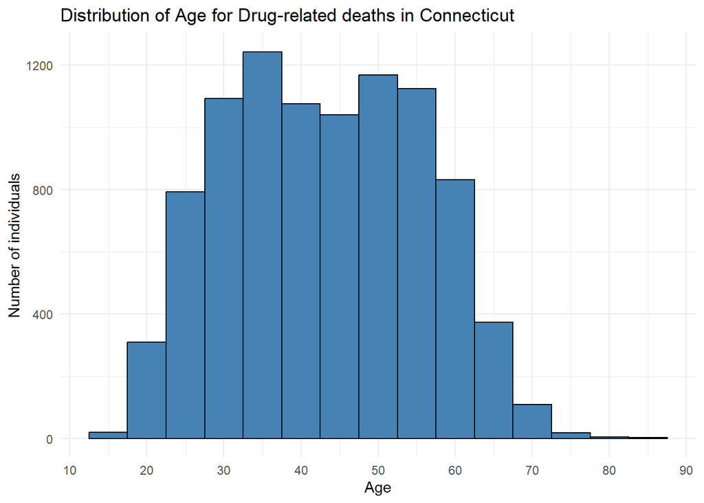

```r
ggplot(selected_data, aes(x=Age)) +
  geom_histogram(fill="steelblue", color="black", binwidth = 5) +
  scale_x_continuous(breaks = seq(0, 120, by = 10)) +
  ggtitle("Distribution of Age for Drug-related deaths in Connecticut") +
  xlab("Age") +
  ylab("Number of individuals") +
  theme_minimal()
```

**2. Gender distribution of individuals younger than 18 for Drug-related deaths in Connecticut:**

Bar plots are useful data visualization tools for presenting the distribution of drug-related deaths across different variables, such as age groups, genders, and drug types. A bar chart is ideal for comparing the frequency or count of different categories and identifying the most common categories.

A bar plot can help visualize the number of drug-related deaths by sex for individuals under the age of 18, allowing healthcare professionals to identify any significant differences in the occurrence of such deaths among males and females in CT.

The process for plotting a bar plot in R using `ggplot2` library is as follows:

- Use dplyr to group the data by the desired column and count the number of occurrences in each group.
- Use ggplot() to create a new plot object.
- Use aes() to specify the x-axis and y-axis data.
- Use geom_bar() to plot the bar chart.
- Use ggtitle(), xlab(), and ylab() to add appropriate titles and labels to the plot.

The code below plots a bar plot in R using `ggplot` library for **“Gender distribution of individuals younger than 18 for Drug-related deaths in Connecticut”**.

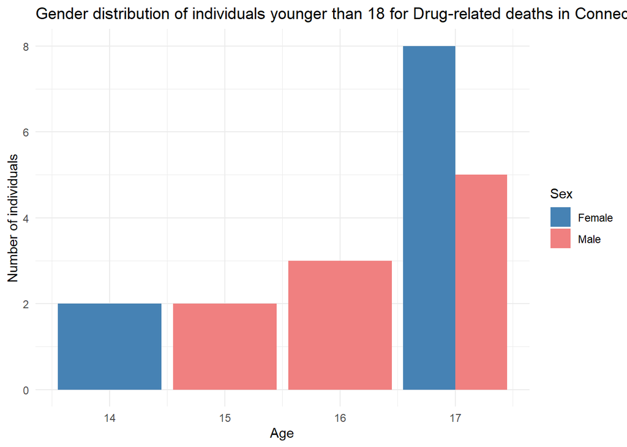

```r
ggplot(sex_age_grp_data, aes(x = Age, y = num_deaths, fill = Sex)) +
  geom_bar(stat = "identity", position = "dodge") +
  ggtitle("Gender distribution of individuals younger than 18 for Drug-related deaths in Connecticut") +
  xlab("Age") +
  ylab("Number of individuals") +
  theme_minimal() +
  scale_fill_manual(values = c("steelblue", "lightcoral"))
```

**Insights:**

One of the key insights from this plot is that the majority of individuals below 18 who died due to drug-related causes were 17 years old. This finding is concerning, as it suggests that many young people are becoming addicted to drugs at an early age, which can have serious long-term consequences for their health and well-being.

**3. Proportion of different Race in Drug-related deaths in Connecticut:**

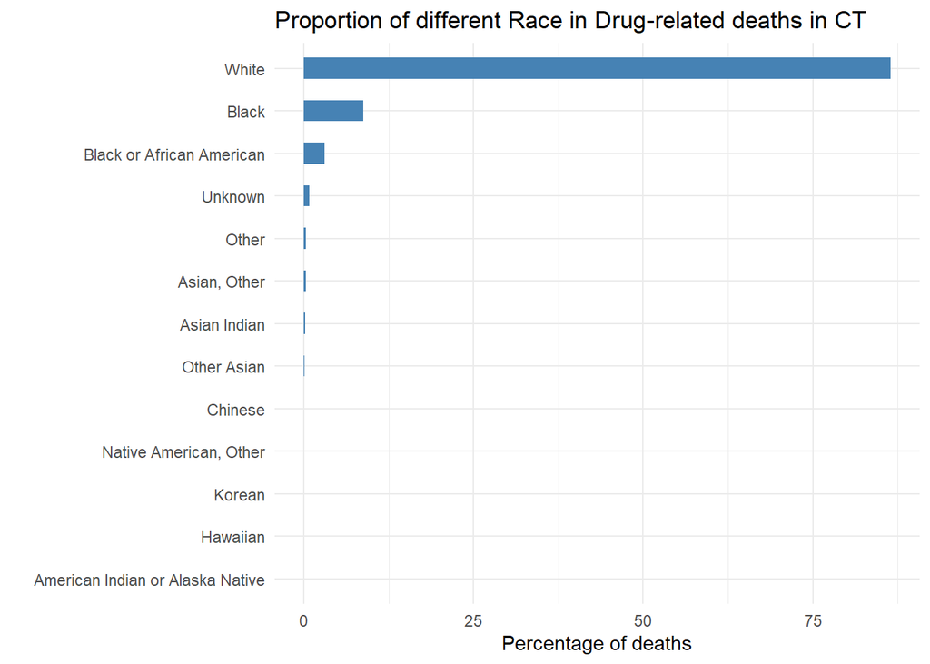

```r
# create a bar chart using ggplot2
ggplot(race_grouped_data, aes(x=Race, y=perc_deaths)) +
  geom_bar(stat="identity", width=0.5, fill="steelblue") +
  labs(title="Proportion of different Race in Drug-related deaths in CT", fill="Race") +
  xlab("") +
  ylab("Percentage of deaths") +
  theme_minimal() +
  coord_flip()
```

**Insights:**

There are likely many factors that contribute to these disparities in drug-related deaths, including differences in access to healthcare and addiction treatment, economic and social factors, and historical and systemic racism. In order to address these disparities, it may be necessary to take a comprehensive and coordinated approach that addresses both the individual and structural factors that contribute to drug addiction and overdose deaths.

**4. Proportion of different Location in Drug-related deaths in Connecticut:**

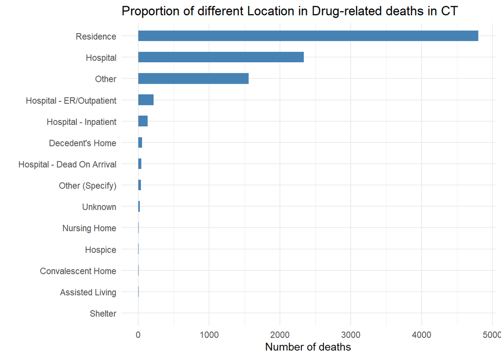

```r
# create a bar chart using ggplot2
ggplot(location_grouped_data, aes(x=Location, y=num_deaths)) +
  geom_bar(stat="identity", width=0.5, fill="steelblue") +
  labs(title="Proportion of different Location in Drug-related deaths in CT", fill="Location") +
  xlab("") +
  ylab("Number of deaths") +
  theme_minimal() +
  coord_flip()
```

**Insights:**

The analysis shows that the majority of individuals who died due to drug-related causes passed away in their own residences, followed by hospitals. This finding is a cause for concern, as it suggests that there may be a lack of adequate support or intervention available to those struggling with drug addiction, particularly in their own homes.

**5. Proportion of different Gender in Drug-related deaths in Connecticut:**

A pie chart is an effective tool for illustrating the proportion or percentage of each category within a whole. By using these charts, healthcare professionals can quickly identify patterns and trends in drug-related deaths and use this information to develop targeted prevention and intervention strategies. A pie chart can help visualize the percentage of drug-related deaths by sex, race, and location of death allowing healthcare professionals to identify patterns and commonality in the occurrence of such deaths among different groups in CT.

The steps for plotting a pie chart using `ggplot2` library in R is as follows:

- Use dplyr to group the data by the desired column and count the number of occurrences in each group.
- Use ggplot() to create a new plot object.
- Use aes() to specify the data and labels.
- Use geom_col() to plot the pie chart.
- Use coord_polar() to convert the chart to a polar coordinate system.
- Use labs() to add an appropriate title to the plot and the legend.

The code plot plots a pie charts for visualizing the **“Proportion of different Gender in Drug-related deaths in Connecticut”**.

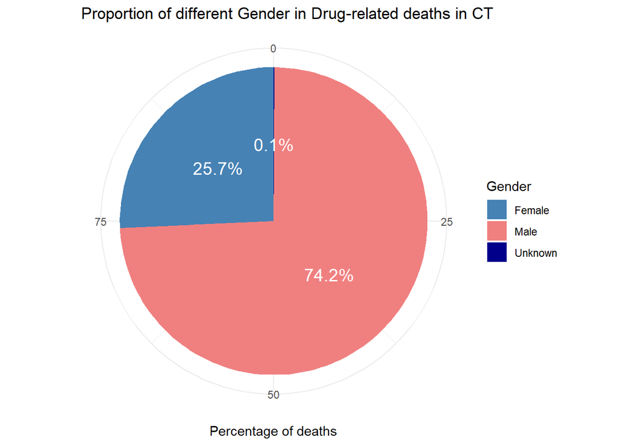

```r
# create a pie chart using ggplot2
ggplot(sex_grouped_data, aes(x="", y=perc_deaths, fill=Sex)) +
  geom_bar(stat="identity", width=1) +
  scale_fill_manual(values = c("steelblue", "lightcoral", "darkblue"))+
  coord_polar(theta="y") +
  labs(title="Proportion of different Gender in Drug-related deaths in CT", fill="Gender") +
  xlab("") +
  ylab("Percentage of deaths") +
  geom_text(aes(label = paste0(round(perc_deaths, 1), "%")), position = position_stack(vjust = 0.5), color = "white", size = 5) +
  theme_minimal()
```

**Insights:**

One of the key insights from this chart is that males dominate the chart, accounting for 75% of all drug-related deaths. This finding suggests that males may be more susceptible to drug addiction and its associated risks.

Another important insight from this chart is that females represent only 25% of drug-related deaths, indicating that they are less affected by drug addiction than males. However, it is important to note that this does not mean that females are immune to the risks of drug addiction, and that targeted interventions and resources may be needed to address the specific needs of this population.

## 3. Conclusion

In conclusion, the data manipulation, tidying and visualization techniques applied in this report have provided valuable insights into the extent and impact of accidental drug-related deaths in Connecticut. Through visualizing the data in various ways, including histograms, bar plots, and pie charts, we have been able to identify important trends and patterns, such as the most commonly involved groups and the demographics of the victims.

These insights can be used by healthcare professionals and policymakers to develop targeted prevention and intervention strategies that are more effective and efficient in addressing the drug-related death epidemic. Furthermore, the use of data visualization has facilitated a better understanding of the underlying issues and risk factors associated with drug abuse and overdose. As the drug-related death epidemic continues to impact communities across the United States, data analysis and visualization remains a critical tool for healthcare professionals and policymakers to effectively combat this public health crisis. The insights and recommendations derived from the techniques employed in this report can serve as a starting point for further research and policy development aimed at reducing the number of drug-related deaths in Connecticut and beyond.

## 4. References

Connecticut Data (2021). Accidental Drug-Related Deaths 2012-2021. Retrieved from https://data.ct.gov/Health-and-Human-Services/Accidental-Drug-Related-Deaths-2012-2021/rybz-nyjwLinks

Centers for Disease Control and Prevention (CDC) (2021, November 17). New CDC data show drug overdose deaths increased in 2020, driven by synthetic opioids. Retrieved from https://www.cdc.gov/nchs/pressroom/nchs_press_releases/2021/20211117.htm

Hedegaard H, Minino AM, Warner M. (2020). Drug overdose deaths in the United States, 1999–2019. NCHS Data Brief, no 394. Hyattsville, MD: National Center for Health Statistics.

Kaiser Family Foundation. (2021). Opioid Overdose Deaths by Race/Ethnicity. Retrieved from https://www.kff.org/other/state-indicator/opioid-overdose-deaths-by-raceethnicity/?currentTimeframe=0&sortModel=%7B%22colId%22:%22Location%22,%22sort%22:%22asc%22%7D

Nahhas, R. W. (n.d.). Inspecting and transforming data. In Introduction to R. Retrieved from https://bookdown.org/rwnahhas/IntroToR/inspect.html

University of Cincinnati Research & Development Center. (n.d.). Pipe: An introduction to the magrittr-style pipes in R. Retrieved February 23, 2023, from https://uc-r.github.io/pipe

Wickham, H. (2014). Tidy data. Journal of Statistical Software, 59(10), 1-23. Retrieved from https://vita.had.co.nz/papers/tidy-data.pdf

Wickham, H. (n.d.). tidyr: Easily Tidy Data with ‘spread()’ and ‘gather()’ Functions. The Comprehensive R Archive Network (CRAN). Retrieved January 25, 2023, from https://cran.r-project.org/web/packages/tidyr/vignettes/pivot.html

Wickham, H., Danenberg, M., Eugster, R., Goulet, L., Loman, T., Takahashi, I., & Vaughan, D. (2019). Visualizing complex data with R: lessons learned from the trenches. Journal of Big Data. https://doi.org/10.1186/s40537-019-0191-1